# structure plots and heat maps for K = 2

We first look at the structure plot

```r
library(gplots)
library(smash)
path = "D:/Grad School/projects/sequence_clustering"
setwd(path)
load("results/analysis_oas1/res_nosmooth_2.RData")
res_nosmooth = res
load("results/analysis_oas1/res_smooth_2.RData")
res_smooth = res
load(paste0(path, "/data/oas1/OAS1.Robj"))
```

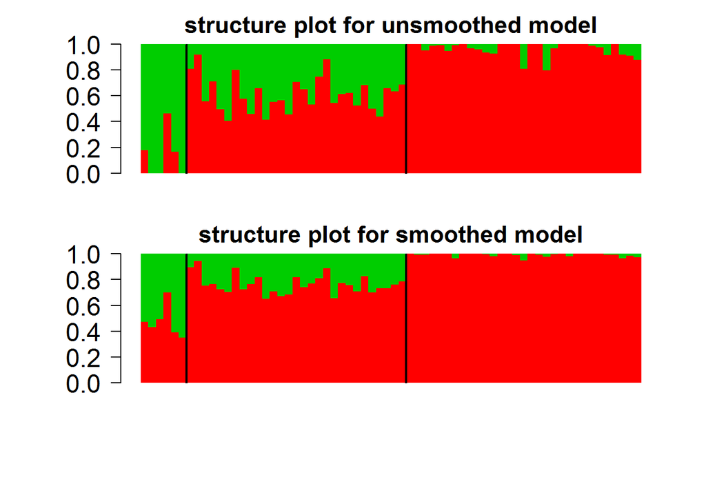

```r
K = dim(res_nosmooth$pi)[2]
nosmooth_pi_unordered = res_nosmooth$pi
ordering = order(Robj$g)
nosmooth_pi_ordered = nosmooth_pi_unordered[ordering, ]
smooth_pi_unordered = res_smooth$pi
smooth_pi_ordered = smooth_pi_unordered[ordering, ]
sep_lines = cumsum(table(Robj$g))[1:2]

par(mfrow = c(2, 1), mar=c(2, 2, 2, 2), oma = c(4, 4, 0.2, 0.2))
barplot(t(nosmooth_pi_ordered), col = 2:3, axisnames = F, space = 0, border = NA, main = "structure plot for unsmoothed model", las = 1, ylim = c(0, 1), cex.axis = 1.5, cex.main = 1.4)
abline(v = sep_lines, lwd = 2)
barplot(t(smooth_pi_ordered), col = 2:3, axisnames = F, space = 0, border = NA, main = "structure plot for smoothed model", las = 1, ylim = c(0, 1), cex.axis = 1.5, cex.main = 1.4)
abline(v = sep_lines, lwd = 2)
```

Now we take a look at the heatmap for genotypes 1 and 2. First heatmap shows correlation for raw reads, second shows correlation for admixture proportions using the model with no smoothing, and the third shows correlation for admixture proportions using the model with smoothing.

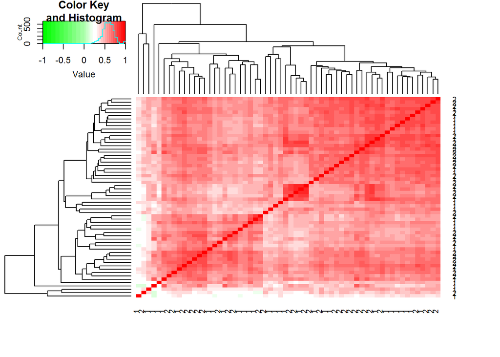

```r
data_subset = data[Robj$g!=0, 2049:4096]
g_subset = Robj$g[Robj$g != 0]

col = c(rgb(seq(0, 1, length = 15), 1, seq(0, 1, length = 15)), rgb(1, seq(1, 0 ,length = 15), seq(1, 0, length = 15)))

heatmap.2(cor(t(data_subset), method = "pearson"), labCol = g_subset, labRow = g_subset, scale = "none", trace = "none", distfun = function(x) dist(x, method = "euclidean"), col = col, hclustfun = function(x) hclust(x,method="average"), breaks = c(seq(-1, 0, 0.1), seq(0.05, 1, length.out = 20)))
```

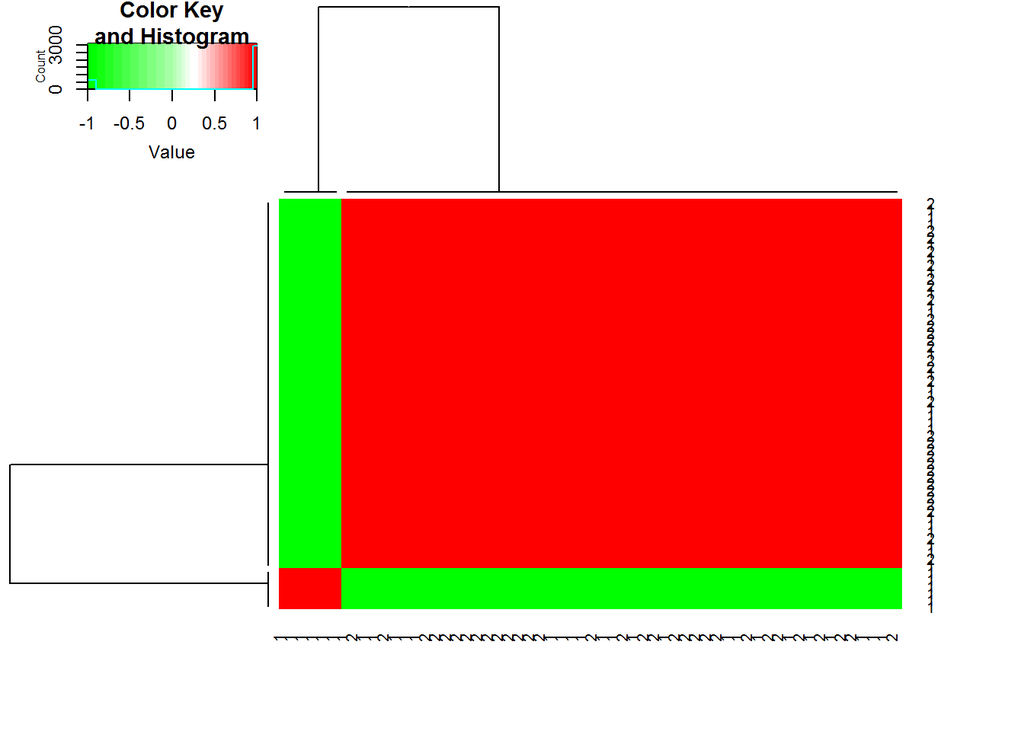

```r
nosmooth_subset = res_nosmooth$pi[Robj$g!=0, ]

hm_nosmooth_12 = heatmap.2(cor(t(nosmooth_subset), method = "pearson"), labCol = g_subset, labRow = g_subset, scale = "none", trace = "none", distfun = function(x) dist(x, method = "euclidean"), col = col, hclustfun = function(x) hclust(x,method="average"), breaks = c(seq(-1, 0, 0.1), seq(0.05, 1, length.out = 20)))
```

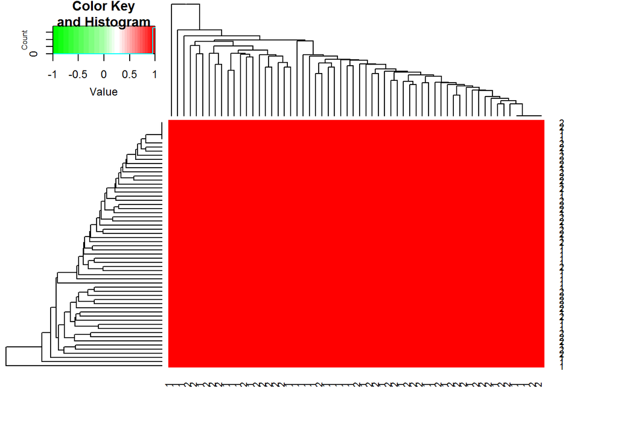

```r
smooth_subset = res_smooth$pi[Robj$g!=0, ]

heatmap.2(cor(t(smooth_subset), method = "pearson"), labCol = g_subset, labRow = g_subset, scale = "none", trace = "none", distfun = function(x) dist(x, method = "euclidean"), col = col, hclustfun = function(x) hclust(x,method="average"), breaks = c(seq(-1, 0, 0.1), seq(0.05, 1, length.out = 20)))
```

Here the model without smoothing seems to pick out a bunch of samples from genotype class 1 that are different from the others. However, the model with smoothing has a difficult time separating out the two classes, due to the fact that both classes have a high proportion in the red cluster to capture the third peak.

Now we draw the same heatmaps, but for genotypes 0 and 2.

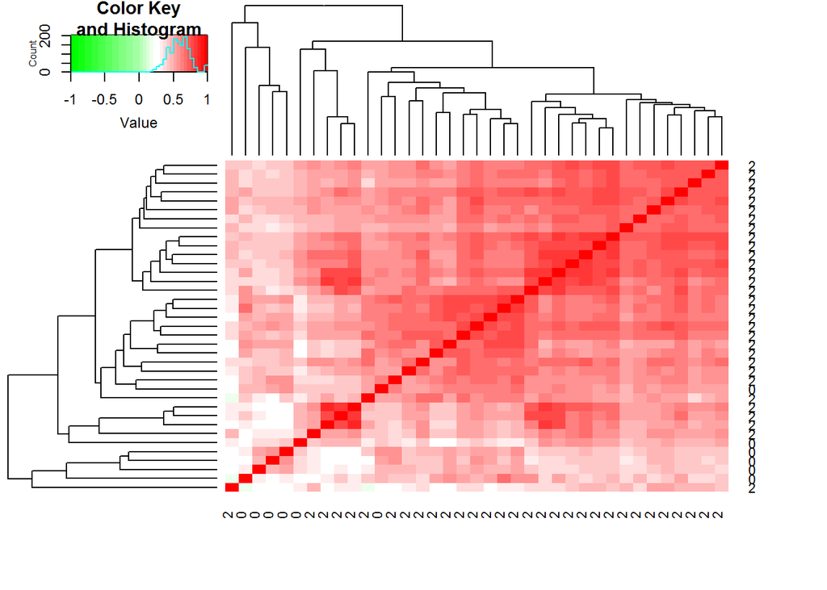

```r
data_subset = data[Robj$g!=1, 2049:4096]
g_subset = Robj$g[Robj$g != 1]

col = c(rgb(seq(0, 1, length = 15), 1, seq(0, 1, length = 15)), rgb(1, seq(1, 0 ,length = 15), seq(1, 0, length = 15)))

heatmap.2(cor(t(data_subset), method = "pearson"), labCol = g_subset, labRow = g_subset, scale = "none", trace = "none", distfun = function(x) dist(x, method = "euclidean"), col = col, hclustfun = function(x) hclust(x,method="average"), breaks = c(seq(-1, 0, 0.1), seq(0.05, 1, length.out = 20)))
```

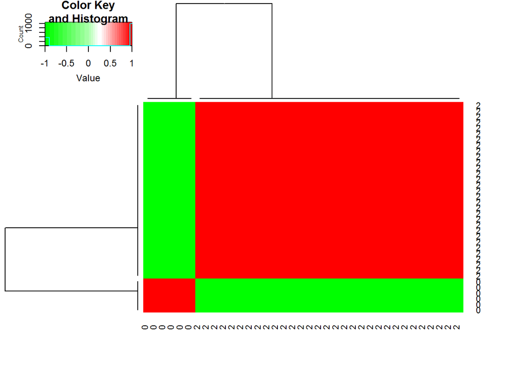

```r
nosmooth_subset = res_nosmooth$pi[Robj$g!=1, ]

hm_nosmooth_02 = heatmap.2(cor(t(nosmooth_subset), method = "pearson"), labCol = g_subset, labRow = g_subset, scale = "none", trace = "none", distfun = function(x) dist(x, method = "euclidean"), col = col, hclustfun = function(x) hclust(x,method="average"), breaks = c(seq(-1, 0, 0.1), seq(0.05, 1, length.out = 20)))
```

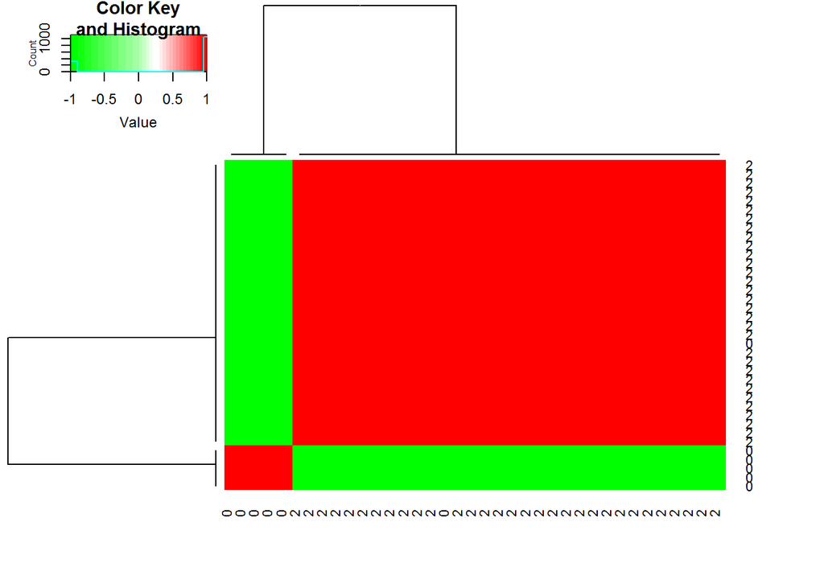

```r
smooth_subset = res_smooth$pi[Robj$g!=1, ]

hm_smooth_02 = heatmap.2(cor(t(smooth_subset), method = "pearson"), labCol = g_subset, labRow = g_subset, scale = "none", trace = "none", distfun = function(x) dist(x, method = "euclidean"), col = col, hclustfun = function(x) hclust(x,method="average"), breaks = c(seq(-1, 0, 0.1), seq(0.05, 1, length.out = 20)))
```

Both models can capture the difference between 0 and 2; however, the model with smoothing classifies one of the samples from 0 as being more similar to 2.

Finally, for genotypes 0 and 1

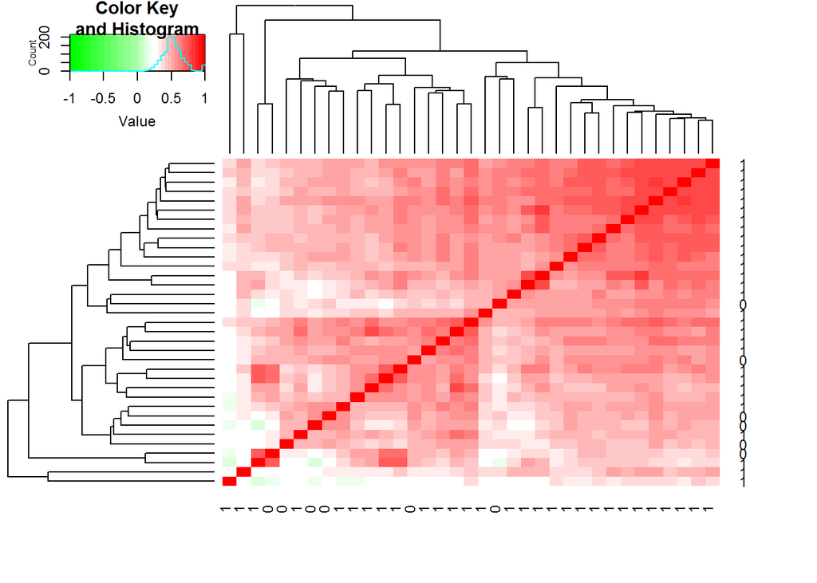

```r
data_subset = data[Robj$g!=2, 2049:4096]
g_subset = Robj$g[Robj$g != 2]

col = c(rgb(seq(0, 1, length = 15), 1, seq(0, 1, length = 15)), rgb(1, seq(1, 0 ,length = 15), seq(1, 0, length = 15)))

heatmap.2(cor(t(data_subset), method = "pearson"), labCol = g_subset, labRow = g_subset, scale = "none", trace = "none", distfun = function(x) dist(x, method = "euclidean"), col = col, hclustfun = function(x) hclust(x,method="average"), breaks = c(seq(-1, 0, 0.1), seq(0.05, 1, length.out = 20)))
```

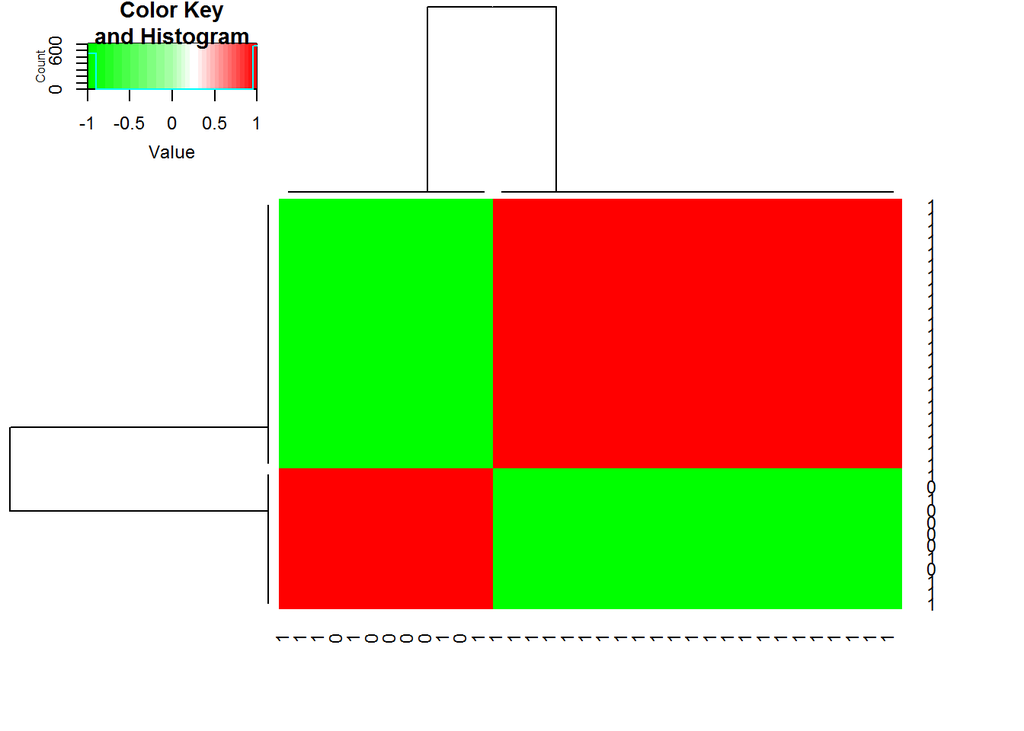

```r
nosmooth_subset = res_nosmooth$pi[Robj$g!=2, ]

hm_nosmooth_01 = heatmap.2(cor(t(nosmooth_subset), method = "pearson"), labCol = g_subset, labRow = g_subset, scale = "none", trace = "none", distfun = function(x) dist(x, method = "euclidean"), col = col, hclustfun = function(x) hclust(x,method="average"), breaks = c(seq(-1, 0, 0.1), seq(0.05, 1, length.out = 20)))
```

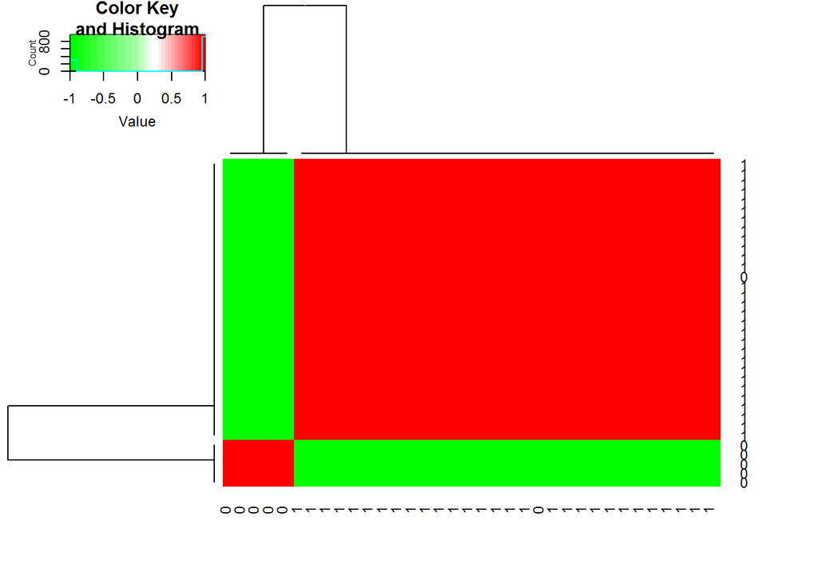

```r
smooth_subset = res_smooth$pi[Robj$g!=2, ]

hm_smooth_01 = heatmap.2(cor(t(smooth_subset), method = "pearson"), labCol = g_subset, labRow = g_subset, scale = "none", trace = "none", distfun = function(x) dist(x, method = "euclidean"), col = col, hclustfun = function(x) hclust(x,method="average"), breaks = c(seq(-1, 0, 0.1), seq(0.05, 1, length.out = 20)))
```

Here model without smoothing has a hard time separating out the two classes, but model with smoothing does a good job.

Overall, it seems like 3 clusters are needed to capture the information contained in this part of the OAS1 gene for the sQTL.